# EdMOOC-Survival: Basic Analysis

### Fitting to prior knowledge

There is very little prior knowledge to go on since the pre-course survey data and even basic demographic data is not available. We do have a proxy for country/region in IP address of last access. Although there is no particular reason - aside from largely unsubstantiated cultural stereotyping - to expect that this is a significant indicator of survival, we will investigate in the absence of more promising alternatives.

For all of the following plots, for each course, only those regions with at least 100 participants on day 0 are plotted. Care must be taken in interpreting the plots since some regions, for example Africa, generally has less than a few hundred participants so the size of the confidence band may be sufficiently large to cover fitted survival curves that appear to be quite far away from it. Smaller samples are less likely to be representative of the population they are drawn from.

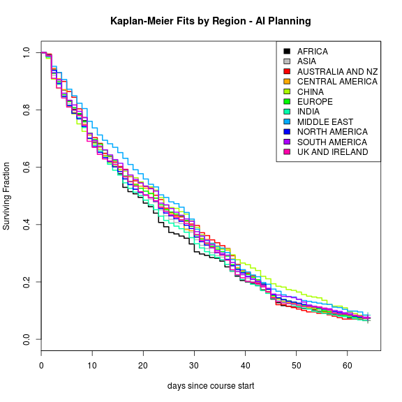

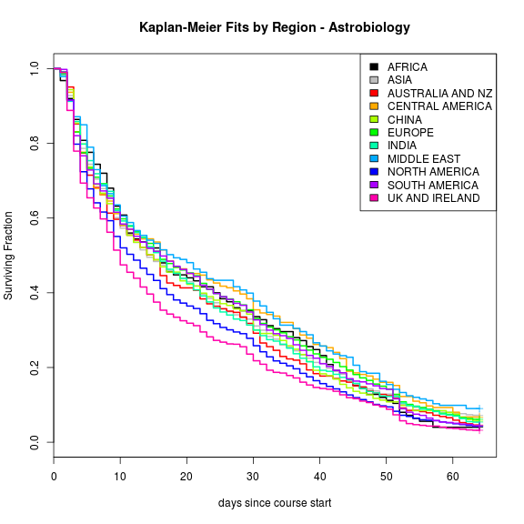

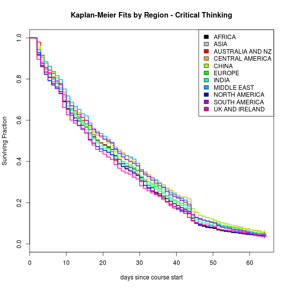

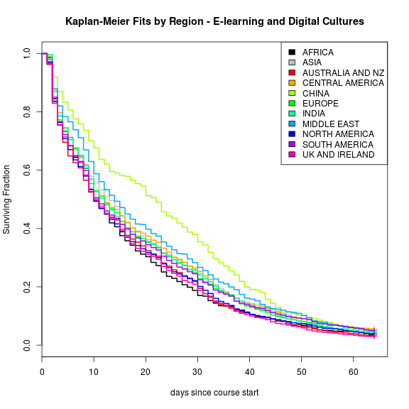

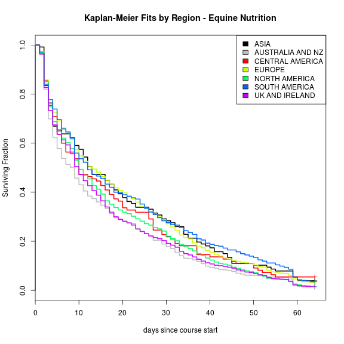

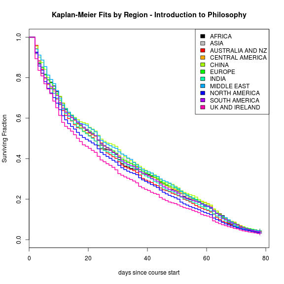

Applying a log-rank test to determine whether the region of the participant makes no significant difference to survival (i.e. the null hypothesis) produces the following p values. Most are sown as zero since they are exceptionally small in magnitude. Only for AI Planning is there insufficient evidence to reject the null hypothesis and that course will not be considered further in this section.

| id | aiplan | astro | crit | edc | equine | intro |
| --- | --- | --- | --- | --- | --- | --- |
| p | 0.2668 | 0.00 | 0.0 | 0.00 | 0.000 | 0.00 |
| log10(p) | -0.5738 | -19.23 | -14.5 | -12.23 | -9.084 | -32.23 |

### Fitting using early knowledge

In the absence of much prior knowledge maybe we can consider survival from the end of, for example, the first week. Arguably it will generally be the case that capturing information from participation in a fraction of a course provides valuable information because it is from the same context as that under investigation.

## Time-to Last-Access for Achievers

The terminology of “survival” is not particularly appropriate when considering those students who gain an achievement status. The essential facts of the analysis are, however, the same as if looking at the last access time: time-period to a non-repeatable event. Unfortunately, the time of the awarding of a statement of achievement is not available in the database and we must instead use the last access time as previously, and recognise that there is a rather imprecise relationship between these events.

In either case, we would expect the courses to differ considerably since different requirements apply. Using the same time window as for the non-achievers above gives the following plots to show how the proportion of those who will achieve, but have not yet done so by a given time, falls. Bear in mind that the numbers of students, and the proportion of course participants, differs between each plot.

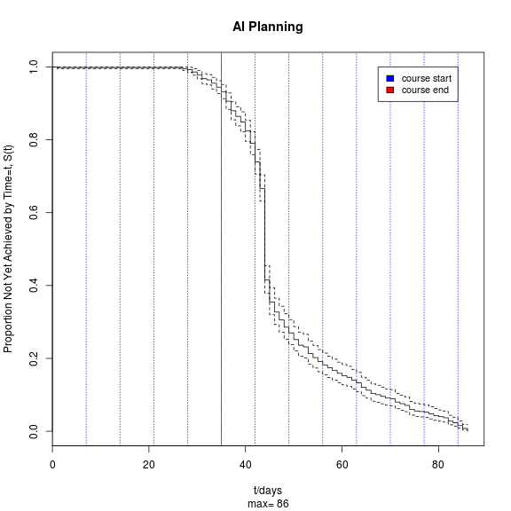

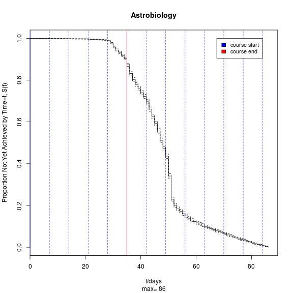

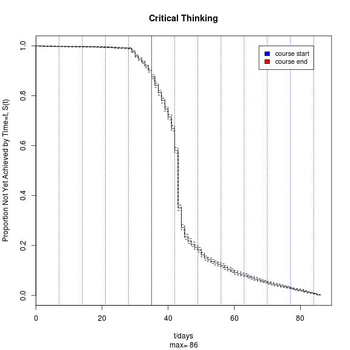

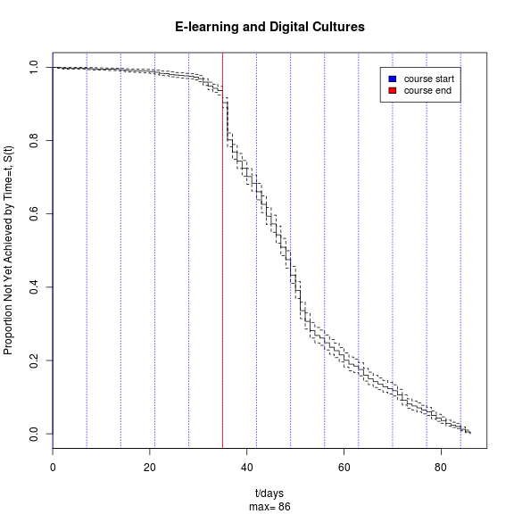

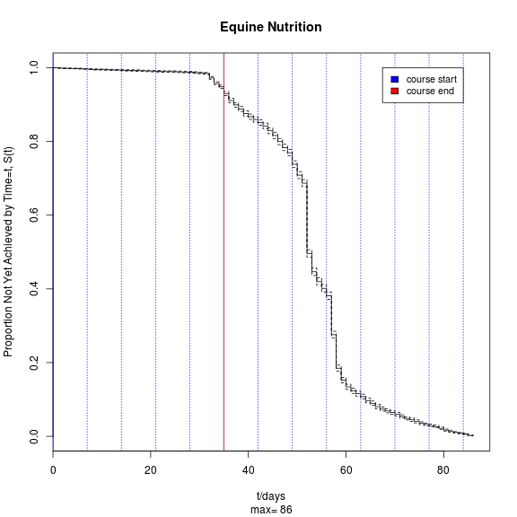

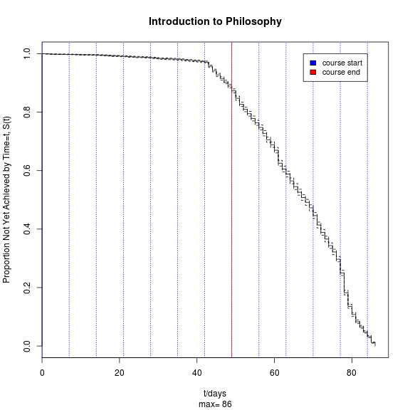

These should all be interpreted with a full knowledge of the assessment component issue dates, deadlines and grade penalties pertinent to each course, as well as the times when manual intervention in issuance of SoAs occurred and the liklihood that notification of award of a SoA would be likely to trigger a visit to the course site (as opposed to the generic coursera user “account” page.

## Pre-Start Attritition

To Do!

## References

R Core Team (2013). R: A language and environment for statistical computing. R Foundation for Statistical Computing, Vienna, Austria. URL http://www.R-project.org/.

Therneau T (2013). *A Package for Survival Analysis in S*. R package version 2.37-4, http://CRAN.R-project.org/package=survival

Terry M. Therneau and Patricia M. Grambsch (2000). *Modeling Survival Data: Extending the Cox Model*. Springer, New York. ISBN 0-387-98784-3.

## About…

The content - source code and outputs - in EdMOOC-Survival were created by Adam Cooper, Cetis, University of Bolton, 2014. The work was undertaken for The University of Edinburgh DEI as part of their MOOC initiative. More information and data analysis is online at http://moocs.is.ed.ac.uk. Source code for EdMOOC-Survival is in GitHub at https://github.com/arc12/EdMOOC-Survival.

[Creative Commons Attribution-NonCommercial 4.0 International License](http://creativecommons.org/licenses/by-nc/4.0/)